# Introduction to Computer Vision: Plant Seedlings Classification

## Problem Statement

### Context

In recent times, the field of agriculture has been in urgent need of modernizing, since the amount of manual work people need to put in to check if plants are growing correctly is still highly extensive. Despite several advances in agricultural technology, people working in the agricultural industry still need to have the ability to sort and recognize different plants and weeds, which takes a lot of time and effort in the long term. The potential is ripe for this trillion-dollar industry to be greatly impacted by technological innovations that cut down on the requirement for manual labor, and this is where Artificial Intelligence can actually benefit the workers in this field, as **the time and energy required to identify plant seedlings will be greatly shortened by the use of AI and Deep Learning.** The ability to do so far more efficiently and even more effectively than experienced manual labor, could lead to better crop yields, the freeing up of human inolvement for higher-order agricultural decision making, and in the long term will result in more sustainable environmental practices in agriculture as well.

### Objective

The aim of this project is to Build a Convolutional Neural Netowrk to classify plant seedlings into their respective categories.

### Data Dictionary

The Aarhus University Signal Processing group, in collaboration with the University of Southern Denmark, has recently released a dataset containing **images of unique plants belonging to 12 different species.**

- The dataset can be download from Olympus.
- The data file names are:
  - images.npy
  - Label.csv
- Due to the large volume of data, the images were converted to the images.npy file and the labels are also put into Labels.csv, so that you can work on the data/project seamlessly without having to worry about the high data volume.
- The goal of the project is to create a classifier capable of determining a plant's species from an image.

**List of Species**

- Black-grass
- Charlock
- Cleavers
- Common Chickweed
- Common Wheat
- Fat Hen
- Loose Silky-bent
- Maize
- Scentless Mayweed
- Shepherds Purse
- Small-flowered Cranesbill
- Sugar beet

#### **Note: Please use GPU runtime to execute the code efficiently**

## Importing necessary libraries

```python
import os
import numpy as np                                                                               # Importing numpy for Matrix Operations
import pandas as pd                                                                              # Importing pandas to read CSV files
import matplotlib.pyplot as plt                                                                  # Importting matplotlib for Plotting and visualizing images
import math                                                                                      # Importing math module to perform mathematical operations
import cv2                                                                                       # Importing openCV for image processing
import seaborn as sns
from sklearn import metrics                                                                            # Importing seaborn to plot graphs


# Tensorflow modules
import tensorflow as tf
from tensorflow.keras.preprocessing.image import ImageDataGenerator                              # Importing the ImageDataGenerator for data augmentation
from tensorflow.keras.models import Sequential                                                   # Importing the sequential module to define a sequential model
from tensorflow.keras.layers import Dense,Dropout,Flatten,Conv2D,MaxPooling2D,BatchNormalization # Defining all the layers to build our CNN Model
from tensorflow.keras.optimizers import Adam,SGD                                                 # Importing the optimizers which can be used in our model
from sklearn import preprocessing                                                                # Importing the preprocessing module to preprocess the data
from sklearn.model_selection import train_test_split                                             # Importing train_test_split function to split the data into train and test
from sklearn.metrics import confusion_matrix                                                     # Importing confusion_matrix to plot the confusion matrix
from sklearn.preprocessing import LabelBinarizer
# Display images using OpenCV
from google.colab.patches import cv2_imshow                                                      # Importing cv2_imshow from google.patches to display images
from sklearn.model_selection import train_test_split
from tensorflow.keras import backend
from keras.callbacks import ReduceLROnPlateau
import random
# Ignore warnings
import warnings
warnings.filterwarnings('ignore')
```

## Loading the dataset

```python
# Mount Google drive to access the dataset
# Run the below code if you using google colab
from google.colab import drive
drive.mount('/content/drive')
```

```python
# Load the image file of dataset
images = np.load('/content/drive/MyDrive/PGPAIML/Module6_Introduction_to_Computer_Vision/Project/images.npy')      # Complete the code to read the dataset

# Load the labels file of dataset
labels = pd.read_csv('/content/drive/MyDrive/PGPAIML/Module6_Introduction_to_Computer_Vision/Project/Labels.csv')  # Complete the code to read the dataset
```

## Data Overview

### Understand the shape of the dataset

```python
print(" Image sshape: " )
print(images.shape )

print("\n Labels shape: " )
print(labels.shape)
```

```
 Image sshape:
(4750, 128, 128, 3)

 Labels shape:
(4750, 1)
```

```python
labels.head()
```

|  | Label |
| --- | --- |
| 0 | Small-flowered Cranesbill |
| 1 | Small-flowered Cranesbill |
| 2 | Small-flowered Cranesbill |
| 3 | Small-flowered Cranesbill |
| 4 | Small-flowered Cranesbill |

```python
labels.describe
```

```
<bound method NDFrame.describe of                           Label
0     Small-flowered Cranesbill
1     Small-flowered Cranesbill
2     Small-flowered Cranesbill
3     Small-flowered Cranesbill
4     Small-flowered Cranesbill
...                         ...
4745           Loose Silky-bent
4746           Loose Silky-bent
4747           Loose Silky-bent
4748           Loose Silky-bent
4749           Loose Silky-bent

[4750 rows x 1 columns]>
```

Adding the list of given species in a collection:

**List of Species**

- Black-grass
- Charlock
- Cleavers
- Common Chickweed
- Common Wheat
- Fat Hen
- Loose Silky-bent
- Maize
- Scentless Mayweed
- Shepherds Purse
- Small-flowered Cranesbill
- Sugar beet

```python
categories = ['Black-grass', 'Charlock', 'Cleavers', 'Common Chickweed', 'Common wheat', 'Fat Hen', 'Loose Silky-bent',
              'Maize', 'Scentless Mayweed', 'Shepherds Purse', 'Small-flowered Cranesbill', 'Sugar beet']
num_categ = len(categories)
num_categ
```

```
12
```

## Exploratory Data Analysis

### Plotting random images from each of the class¶

```python
def plot_images(images,labels):
  num_classes=10                                                                  # Number of Classes
  categories=np.unique(labels)
  keys=dict(labels['Label'])                                                      # Obtaing the unique classes from y_train
  rows = 3                                                                        # Defining number of rows=3
  cols = 4                                                                        # Defining number of columns=4
  fig = plt.figure(figsize=(10, 8))                                               # Defining the figure size to 10x8
  for i in range(cols):
      for j in range(rows):
          random_index = np.random.randint(0, len(labels))                        # Generating random indices from the data and plotting the images
          ax = fig.add_subplot(rows, cols, i * rows + j + 1)                      # Adding subplots with 3 rows and 4 columns
          ax.imshow(images[random_index, :])                                      # Plotting the image
          ax.set_title(keys[random_index])
  plt.show()
```

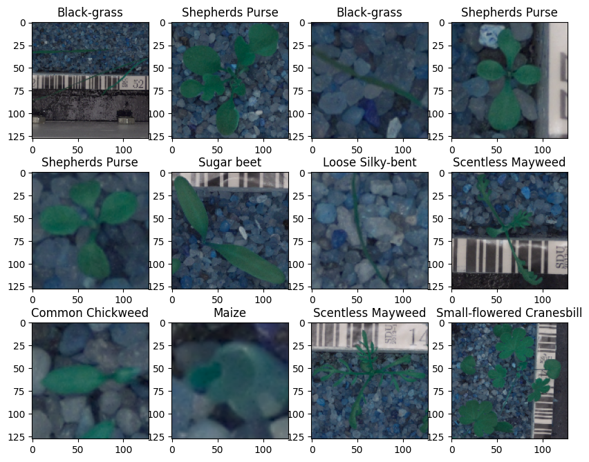

```python
plot_images(images, labels)
```

### Checking the distribution of the target variable

[output not shown]

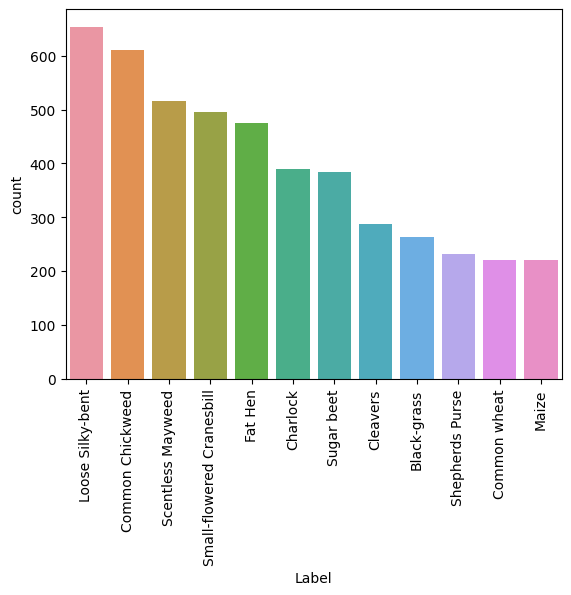

```python
sns.countplot(x=labels['Label'],order = labels['Label'].value_counts().index)
plt.xticks(rotation='vertical')
```

#### Observations:

More samples of the "Loose Silky bent" plant category are available compared to other categories. "Common Wheat" and "Maize" have the fewest samples.

## Data Pre-Processing

### Convert the BGR images to RGB images.

```python
# Converting the images from BGR to RGB using cvtColor function of OpenCV
for i in range(len(images)):
  images[i] = cv2.cvtColor(images[i], cv2.COLOR_BGR2RGB)
```

### Resize the images

As the size of the images is large, it may be computationally expensive to train on these larger images; therefore, it is preferable to reduce the image size from 128 to 64.

```python
images_decreased=[]
height = 64  # Define the height as 64
width = 64   # Define the width as 64
dimensions = (width, height)
for i in range(len(images)):
  images_decreased.append(cv2.resize(images[i], dimensions, interpolation=cv2.INTER_LINEAR))
```

```python
plt.imshow(images[3])
```

[output not shown]

##### 1. Image post decreasing

```python
plt.imshow(images_decreased[3])
```

[output not shown]

[figure not shown]

```python
plt.imshow(images[30])
```

##### 2. Image post decreasing

[figure not shown]

```python
plt.imshow(images_decreased[30])
```

[figure not shown]

```python
plt.imshow(images[101])
```

### Data Preparation for Modeling

- Before you proceed to build a model, you need to split the data into train, test, and validation to be able to evaluate the model that you build on the train data
- You'll have to encode categorical features and scale the pixel values.
- You will build a model using the train data and then check its performance

**Split the dataset**

```python
X_temp, X_test, y_temp, y_test = train_test_split(np.array(images_decreased), labels, test_size=0.1, random_state=42, stratify=labels)
X_train, X_val, y_train, y_val = train_test_split(X_temp, y_temp, test_size=0.1, random_state=42, stratify=y_temp)
```

```python
print("Training dataset: "); print(X_train.shape, y_train.shape); print("\n ")

print("Validation dataset: "); print(X_val.shape, y_val.shape); print("\n ")

print("Testing dataset: "); print(X_test.shape, y_test.shape); print("\n ")
```

```
Training dataset:
(3847, 64, 64, 3) (3847, 1)


Validation dataset:
(428, 64, 64, 3) (428, 1)


Testing dataset:
(475, 64, 64, 3) (475, 1)
```

### Observations

**Testing Dataset:**

- Reserved for evaluating the model's performance on new, unseen data.
- It consists of 475 samples, sharing the same image dimensions and label format as the training and validation sets.

### Encode the target labels

```python
enc = LabelBinarizer()
y_train_encoded = enc.fit_transform(y_train)
y_val_encoded = enc.transform(y_val)
y_test_encoded = enc.transform(y_test)
```

```python
print("y_train_encoded")
print(y_train_encoded.shape)


print("y_val_encoded")
print(y_val_encoded.shape)

print("y_test_encoded")
print(y_test_encoded.shape)
```

```
y_train_encoded
(3847, 12)
y_val_encoded
(428, 12)
y_test_encoded
(475, 12)
```

### Observations:

1. **y_train_encoded:**
   - The encoded labels for the training set have a shape of (3847, 12).
   - There are 3,847 samples in the training set, and each sample is represented by a one-hot encoded array of length 12, suggesting a multi-class classification task with 12 classes.
2. **y_val_encoded:**
   - The encoded labels for the validation set have a shape of (428, 12).
   - The validation set contains 428 samples, and similar to the training set, each sample is represented by a one-hot encoded array of length 12.
3. **y_test_encoded:**
   - The encoded labels for the testing set have a shape of (475, 12).
   - The testing set consists of 475 samples, and the label encoding follows the same pattern as the training and validation sets, with arrays of length 12.

In summary, the label encoding is consistent across all datasets, suggesting a multi-class classification problem with 12 distinct classes. Each sample is represented by a one-hot encoded array indicating its class. The sizes of the encoded label arrays match the corresponding sizes of the datasets.

### Data Normalization

Given that the pixel values in the images span from 0 to 255, our normalization approach involves scaling. Specifically, we will standardize the images by dividing all pixel values by 255, ensuring that the resulting values fall within the range of 0 to 1.

```python
X_train_normalized = X_train.astype('float32') / 255.0
X_val_normalized = X_val.astype('float32') / 255.0
X_test_normalized = X_test.astype('float32') / 255.0
```

## Model Building

```python
# Clearing backend
backend.clear_session()
```

```python
# Fixing the seed for random number generators
np.random.seed(42)
random.seed(42)
tf.random.set_seed(42)
```

```python
# Intializing a sequential model
model1 = Sequential()

# Adding the first conv layer with 128 filters and kernel size 3x3, padding 'same' provides the output size same as the input size
# Input_shape denotes input image dimension of images
model1.add(Conv2D(128, (3, 3), activation='relu', padding="same", input_shape=(64, 64, 3)))

# Adding the max pooling to reduce the size of output of the first conv layer
model1.add(MaxPooling2D((2, 2), padding='same'))

# Creating two similar convolution and max-pooling layers activation = relu
model1.add(Conv2D(64, (3, 3), activation='relu', padding="same"))
model1.add(MaxPooling2D((2, 2), padding='same'))

model1.add(Conv2D(32, (3, 3), activation='relu', padding="same"))
model1.add(MaxPooling2D((2, 2), padding='same'))

# Flattening the output of the conv layer after max pooling to make it ready for creating dense connections
model1.add(Flatten())

# Adding a fully connected dense layer with 16 neurons
model1.add(Dense(16, activation='relu'))
model1.add(Dropout(0.3))

# Adding the output layer with 12 neurons and activation function as softmax since this is a multi-class classification problem
model1.add(Dense(12, activation='softmax'))

# Using the Adam Optimizer
opt = Adam()

# Compiling the model using categorical cross-entropy for loss function
model1.compile(optimizer=opt, loss='categorical_crossentropy', metrics=['accuracy'])

# Generating the summary of the model
model1.summary()
```

```
Model: "sequential"
_________________________________________________________________
 Layer (type)                Output Shape              Param #
=================================================================
 conv2d (Conv2D)             (None, 64, 64, 128)       3584

 max_pooling2d (MaxPooling2  (None, 32, 32, 128)       0
 D)

 conv2d_1 (Conv2D)           (None, 32, 32, 64)        73792

 max_pooling2d_1 (MaxPoolin  (None, 16, 16, 64)        0
 g2D)

 conv2d_2 (Conv2D)           (None, 16, 16, 32)        18464

 max_pooling2d_2 (MaxPoolin  (None, 8, 8, 32)          0
 g2D)

 flatten (Flatten)           (None, 2048)              0

 dense (Dense)               (None, 16)                32784

 dropout (Dropout)           (None, 16)                0

 dense_1 (Dense)             (None, 12)                204

=================================================================
Total params: 128828 (503.23 KB)
Trainable params: 128828 (503.23 KB)
Non-trainable params: 0 (0.00 Byte)
_________________________________________________________________
```

### Observations:

The model with sequential architecture comprising various layers:

1. **Convolutional Layer 1:** Generates an output shape of (64, 64, 128) with 3,584 parameters.
2. **Max Pooling Layer 1:** Reduces dimensions to (32, 32, 128) without introducing new trainable parameters.
3. **Convolutional Layer 2:** Produces an output shape of (32, 32, 64) with 73,792 parameters.
4. **Max Pooling Layer 2:** Further reduces dimensions to (16, 16, 64) without adding trainable parameters.
5. **Convolutional Layer 3:** Yields an output shape of (16, 16, 32) with 18,464 parameters.
6. **Max Pooling Layer 3:** Reduces dimensions to (8, 8, 32) without introducing new trainable parameters.
7. **Flatten Layer:** Flattens the output to (2048) with no trainable parameters.
8. **Dense Layer 1:** A fully connected layer with 32,784 parameters and 16 neurons.
9. **Dropout Layer:** Implements dropout regularization with no additional trainable parameters.
10. **Dense Layer 2:** Another fully connected layer with 204 parameters and 12 neurons, representing the final output classes.

The model encompasses a total of 128,828 parameters, all of which are trainable. It utilizes convolutional and pooling layers to capture hierarchical features in the input data, followed by dense layers for classification. The incorporation of a dropout layer aims to prevent overfitting during the training process.

```python
# Fitting the model on train and also using the validation data for validation
history_1 = model1.fit(
    X_train_normalized, y_train_encoded,
    epochs=60,
    validation_data=(X_val_normalized, y_val_encoded),
    batch_size=64,
    verbose=2
)
```

```
61/61 - 15s - loss: 2.4589 - accuracy: 0.1027 - val_loss: 2.4508 - val_accuracy: 0.1379 - 15s/epoch - 243ms/step
61/61 - 1s - loss: 2.4424 - accuracy: 0.1183 - val_loss: 2.4327 - val_accuracy: 0.1379 - 1s/epoch - 17ms/step
61/61 - 1s - loss: 2.3869 - accuracy: 0.1677 - val_loss: 2.1880 - val_accuracy: 0.2921 - 1s/epoch - 17ms/step
61/61 - 1s - loss: 2.1020 - accuracy: 0.2807 - val_loss: 1.8819 - val_accuracy: 0.3224 - 1s/epoch - 16ms/step
61/61 - 1s - loss: 1.9056 - accuracy: 0.3177 - val_loss: 1.8204 - val_accuracy: 0.3692 - 999ms/epoch - 16ms/step
61/61 - 1s - loss: 1.8410 - accuracy: 0.3171 - val_loss: 1.6012 - val_accuracy: 0.4229 - 1s/epoch - 17ms/step
61/61 - 1s - loss: 1.7593 - accuracy: 0.3624 - val_loss: 1.5412 - val_accuracy: 0.4416 - 992ms/epoch - 16ms/step
61/61 - 1s - loss: 1.7011 - accuracy: 0.3746 - val_loss: 1.4732 - val_accuracy: 0.4509 - 1s/epoch - 17ms/step
61/61 - 1s - loss: 1.6516 - accuracy: 0.3902 - val_loss: 1.4528 - val_accuracy: 0.4673 - 1s/epoch - 18ms/step
61/61 - 1s - loss: 1.6331 - accuracy: 0.3990 - val_loss: 1.5371 - val_accuracy: 0.4463 - 1s/epoch - 18ms/step
61/61 - 1s - loss: 1.6103 - accuracy: 0.4141 - val_loss: 1.3615 - val_accuracy: 0.5023 - 1s/epoch - 18ms/step
61/61 - 1s - loss: 1.5399 - accuracy: 0.4268 - val_loss: 1.3914 - val_accuracy: 0.5210 - 1s/epoch - 18ms/step
61/61 - 1s - loss: 1.5313 - accuracy: 0.4458 - val_loss: 1.3513 - val_accuracy: 0.5561 - 1s/epoch - 18ms/step
61/61 - 1s - loss: 1.4688 - accuracy: 0.4676 - val_loss: 1.3546 - val_accuracy: 0.5491 - 1s/epoch - 18ms/step
61/61 - 1s - loss: 1.4400 - accuracy: 0.4726 - val_loss: 1.2584 - val_accuracy: 0.5561 - 1s/epoch - 17ms/step
61/61 - 1s - loss: 1.4752 - accuracy: 0.4682 - val_loss: 1.2898 - val_accuracy: 0.5794 - 997ms/epoch - 16ms/step
61/61 - 1s - loss: 1.4187 - accuracy: 0.4786 - val_loss: 1.2424 - val_accuracy: 0.5607 - 993ms/epoch - 16ms/step
61/61 - 1s - loss: 1.4168 - accuracy: 0.4895 - val_loss: 1.2047 - val_accuracy: 0.5958 - 1s/epoch - 16ms/step
61/61 - 1s - loss: 1.3625 - accuracy: 0.5017 - val_loss: 1.2312 - val_accuracy: 0.5888 - 1s/epoch - 17ms/step
61/61 - 1s - loss: 1.3309 - accuracy: 0.5100 - val_loss: 1.2070 - val_accuracy: 0.6075 - 995ms/epoch - 16ms/step
61/61 - 1s - loss: 1.3209 - accuracy: 0.5181 - val_loss: 1.1780 - val_accuracy: 0.6495 - 1s/epoch - 17ms/step
61/61 - 1s - loss: 1.2739 - accuracy: 0.5290 - val_loss: 1.1420 - val_accuracy: 0.6472 - 1s/epoch - 16ms/step
61/61 - 1s - loss: 1.2808 - accuracy: 0.5329 - val_loss: 1.1847 - val_accuracy: 0.6192 - 1s/epoch - 17ms/step
61/61 - 1s - loss: 1.2577 - accuracy: 0.5363 - val_loss: 1.2024 - val_accuracy: 0.5935 - 1s/epoch - 16ms/step
61/61 - 1s - loss: 1.2460 - accuracy: 0.5386 - val_loss: 1.0996 - val_accuracy: 0.6612 - 1s/epoch - 18ms/step
61/61 - 1s - loss: 1.2164 - accuracy: 0.5526 - val_loss: 1.0894 - val_accuracy: 0.6729 - 1s/epoch - 18ms/step
61/61 - 1s - loss: 1.2182 - accuracy: 0.5506 - val_loss: 1.1409 - val_accuracy: 0.6332 - 1s/epoch - 18ms/step
61/61 - 1s - loss: 1.1677 - accuracy: 0.5558 - val_loss: 1.0877 - val_accuracy: 0.6706 - 1s/epoch - 18ms/step
61/61 - 1s - loss: 1.1991 - accuracy: 0.5547 - val_loss: 1.1262 - val_accuracy: 0.6542 - 1s/epoch - 18ms/step
61/61 - 1s - loss: 1.1580 - accuracy: 0.5747 - val_loss: 1.0563 - val_accuracy: 0.6939 - 1s/epoch - 17ms/step
61/61 - 1s - loss: 1.1799 - accuracy: 0.5591 - val_loss: 1.0536 - val_accuracy: 0.7009 - 1s/epoch - 17ms/step
61/61 - 1s - loss: 1.0921 - accuracy: 0.5981 - val_loss: 1.0276 - val_accuracy: 0.6986 - 1s/epoch - 17ms/step
61/61 - 1s - loss: 1.1256 - accuracy: 0.5950 - val_loss: 1.0509 - val_accuracy: 0.6893 - 1s/epoch - 17ms/step
61/61 - 1s - loss: 1.0844 - accuracy: 0.6023 - val_loss: 1.0844 - val_accuracy: 0.6776 - 1000ms/epoch - 16ms/step
61/61 - 1s - loss: 1.1057 - accuracy: 0.6010 - val_loss: 1.0497 - val_accuracy: 0.6846 - 1s/epoch - 16ms/step
61/61 - 1s - loss: 1.0868 - accuracy: 0.6036 - val_loss: 1.1074 - val_accuracy: 0.6706 - 1s/epoch - 17ms/step
61/61 - 1s - loss: 1.0873 - accuracy: 0.6080 - val_loss: 1.0138 - val_accuracy: 0.6869 - 1s/epoch - 17ms/step
61/61 - 1s - loss: 1.0768 - accuracy: 0.6057 - val_loss: 1.0293 - val_accuracy: 0.7150 - 1s/epoch - 17ms/step
61/61 - 1s - loss: 1.0371 - accuracy: 0.6184 - val_loss: 1.0224 - val_accuracy: 0.6963 - 1s/epoch - 16ms/step
61/61 - 1s - loss: 1.0035 - accuracy: 0.6350 - val_loss: 1.0289 - val_accuracy: 0.7079 - 1s/epoch - 18ms/step
```

[output cut: 20 more lines]

### Model Evaluation

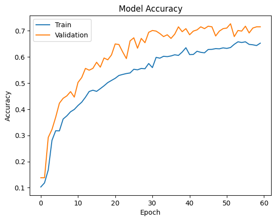

```python
plt.plot(history_1.history['accuracy'])
plt.plot(history_1.history['val_accuracy'])
plt.title('Model Accuracy')
plt.ylabel('Accuracy')
plt.xlabel('Epoch')
plt.legend(['Train', 'Validation'], loc='upper left')
plt.show()
```

### Evaluate the model on test data

```python
# Evaluating the model on test data
accuracy = model1.evaluate(X_test_normalized, y_test_encoded, verbose=2)
```

```
15/15 - 0s - loss: 0.9524 - accuracy: 0.7158 - 262ms/epoch - 17ms/step
```

**Plotting the Confusion Matrix**

```python
# Predicting the output probabilities
y_pred = model1.predict(X_test_normalized)
```

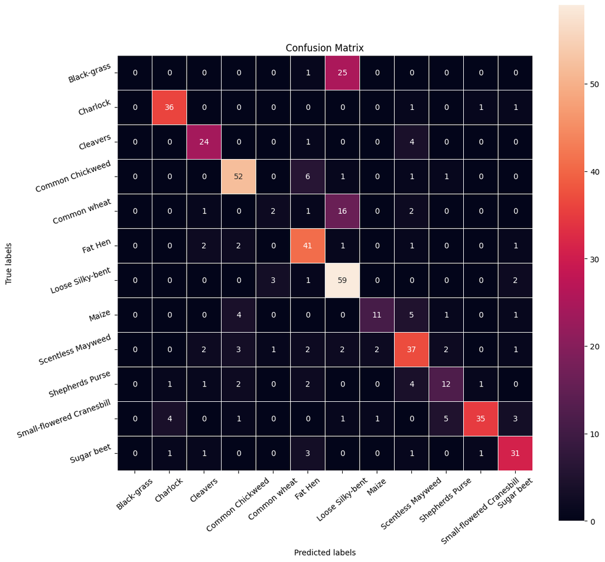

```python
# Obtaining the categorical values from y_test_encoded and y_pred
y_pred_arg = np.argmax(y_pred, axis=1)
y_test_arg = np.argmax(y_test_encoded, axis=1)

# Plotting the Confusion Matrix
confusion_matrix = tf.math.confusion_matrix(y_test_arg, y_pred_arg)
f, ax = plt.subplots(figsize=(12, 12))
sns.heatmap(
    confusion_matrix,
    annot=True,
    linewidths=.4,
    fmt="d",
    square=True,
    ax=ax
)
# Setting the labels to both the axes
ax.set_xlabel('Predicted labels');
ax.set_ylabel('True labels');
ax.set_title('Confusion Matrix');
ax.xaxis.set_ticklabels(list(enc.classes_), rotation=40)
ax.yaxis.set_ticklabels(list(enc.classes_), rotation=20)
plt.show()
```

**Plotting Classification Report**

```python
# Plotting the classification report
cr = metrics.classification_report(y_test_arg, y_pred_arg)
print(cr)
```

```
              precision    recall  f1-score   support

           0       0.00      0.00      0.00        26
           1       0.86      0.92      0.89        39
           2       0.77      0.83      0.80        29
           3       0.81      0.85      0.83        61
           4       0.33      0.09      0.14        22
           5       0.71      0.85      0.77        48
           6       0.56      0.91      0.69        65
           7       0.79      0.50      0.61        22
           8       0.66      0.71      0.69        52
           9       0.57      0.52      0.55        23
          10       0.92      0.70      0.80        50
          11       0.78      0.82      0.79        38

    accuracy                           0.72       475
   macro avg       0.65      0.64      0.63       475
weighted avg       0.68      0.72      0.69       475
```

### Observations

In simpler terms, the model is generally correct 70% of the time, with some classes having more accurate predictions than others. The precision tells us how often the model is right when it makes a positive prediction, while recall indicates how well it captures actual positive instances. The F1-score is a balance between these two aspects.

## Model Performance Improvement

**Reducing the Learning Rate:**

**ReduceLRonPlateau()** is a function that will be used to decrease the learning rate by some factor, if the loss is not decreasing for some time. This may start decreasing the loss at a smaller learning rate. There is a possibility that the loss may still not decrease. This may lead to executing the learning rate reduction again in an attempt to achieve a lower loss.

```python
# Code to monitor val_accuracy
learning_rate_reduction = ReduceLROnPlateau(monitor='val_accuracy',
                                            patience=3,
                                            verbose=1,
                                            factor=0.5,
                                            min_lr=0.00001)
```

### **Data Augmentation**

```python
# Clearing backend
from tensorflow.keras import backend
backend.clear_session()

# Fixing the seed for random number generators
import random
np.random.seed(42)
random.seed(42)
tf.random.set_seed(42)
```

```python
# Complete the code to set the rotation_range to 20
train_datagen = ImageDataGenerator(
    rotation_range=20,
    fill_mode='nearest'
)
```

```python
# Intializing a sequential model
model2 = Sequential()

# Complete the code to add the first conv layer with 64 filters and kernel size 3x3, padding 'same' provides the output size same as the input size
# Input_shape denotes input image dimension images
model2.add(Conv2D(64, (3, 3), activation='relu', padding="same", input_shape=(64, 64, 3)))

# Complete the code to add max pooling to reduce the size of output of first conv layer
model2.add(MaxPooling2D((2, 2), padding='same'))

model2.add(Conv2D(32, (3, 3), activation='relu', padding="same"))
model2.add(MaxPooling2D((2, 2), padding='same'))
model2.add(BatchNormalization())

# flattening the output of the conv layer after max pooling to make it ready for creating dense connections
model2.add(Flatten())

# Adding a fully connected dense layer with 16 neurons
model2.add(Dense(16, activation='relu'))

# Complete the code to add dropout with dropout_rate=0.3
model2.add(Dropout(0.3))
# Complete the code to add the output layer with 12 neurons and activation functions as softmax since this is a multi-class classification problem
model2.add(Dense(12, activation='softmax'))

# Complete the code to initialize Adam Optimimzer
opt = Adam()
# Complete the code to Compile model
model2.compile(optimizer=opt, loss='categorical_crossentropy', metrics=['accuracy'])

# Generating the summary of the model
model2.summary()
```

```
Model: "sequential"
_________________________________________________________________
 Layer (type)                Output Shape              Param #
=================================================================
 conv2d (Conv2D)             (None, 64, 64, 64)        1792

 max_pooling2d (MaxPooling2  (None, 32, 32, 64)        0
 D)

 conv2d_1 (Conv2D)           (None, 32, 32, 32)        18464

 max_pooling2d_1 (MaxPoolin  (None, 16, 16, 32)        0
 g2D)

 batch_normalization (Batch  (None, 16, 16, 32)        128
 Normalization)

 flatten (Flatten)           (None, 8192)              0

 dense (Dense)               (None, 16)                131088

 dropout (Dropout)           (None, 16)                0

 dense_1 (Dense)             (None, 12)                204

=================================================================
Total params: 151676 (592.48 KB)
Trainable params: 151612 (592.23 KB)
Non-trainable params: 64 (256.00 Byte)
_________________________________________________________________
```

### Observations

In essence, this model is structured with convolutional layers for feature extraction, pooling layers for downsampling, batch normalization for stability, and dense layers for classification. The architecture is tailored for image classification, specifically with 12 output classes.

```python
epochs = 60
# Batch size
batch_size = 128

history = model2.fit(train_datagen.flow(X_train_normalized, y_train_encoded,
                                        batch_size=batch_size,
                                        shuffle=False),
                    epochs=epochs,
                    steps_per_epoch=X_train_normalized.shape[0] // batch_size,
                    validation_data=(X_val_normalized, y_val_encoded),
                    verbose=1, callbacks=[learning_rate_reduction])
```

```
Epoch 18: ReduceLROnPlateau reducing learning rate to 0.0005000000237487257.
Epoch 21: ReduceLROnPlateau reducing learning rate to 0.0002500000118743628.
Epoch 29: ReduceLROnPlateau reducing learning rate to 0.0001250000059371814.
Epoch 33: ReduceLROnPlateau reducing learning rate to 6.25000029685907e-05.
Epoch 36: ReduceLROnPlateau reducing learning rate to 3.125000148429535e-05.
Epoch 39: ReduceLROnPlateau reducing learning rate to 1.5625000742147677e-05.
Epoch 42: ReduceLROnPlateau reducing learning rate to 1e-05.
```

**Model Evaluation**

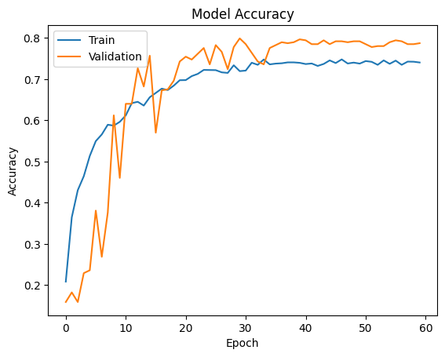

```python
plt.plot(history.history['accuracy'])
plt.plot(history.history['val_accuracy'])
plt.title('Model Accuracy')
plt.ylabel('Accuracy')
plt.xlabel('Epoch')
plt.legend(['Train', 'Validation'], loc='upper left')
plt.show()
```

**Evaluate the model on test data**

```python
accuracy = model2.evaluate(X_test_normalized, y_test_encoded, verbose=2)
```

```
15/15 - 0s - loss: 0.7587 - accuracy: 0.7726 - 149ms/epoch - 10ms/step
```

**Plotting the Confusion Matrix**

```python
y_pred = model2.predict(X_test_normalized)
```

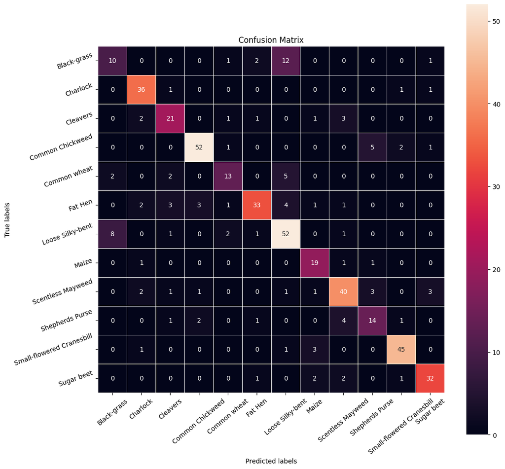

```python
# Obtaining the categorical values from y_test_encoded and y_pred
y_pred_arg = np.argmax(y_pred, axis=1)
y_test_arg = np.argmax(y_test_encoded, axis=1)

# Plotting the Confusion Matrix using confusion matrix() function which is also predefined in tensorflow module
confusion_matrix = tf.math.confusion_matrix(y_test_arg, y_pred_arg)  # Complete the code to obtain the confusion matrix
f, ax = plt.subplots(figsize=(12, 12))
sns.heatmap(
    confusion_matrix,
    annot=True,
    linewidths=.4,
    fmt="d",
    square=True,
    ax=ax
)
# Setting the labels to both the axes
ax.set_xlabel('Predicted labels')
ax.set_ylabel('True labels')
ax.set_title('Confusion Matrix')
ax.xaxis.set_ticklabels(list(enc.classes_), rotation=40)
ax.yaxis.set_ticklabels(list(enc.classes_), rotation=20)
plt.show()
```

**Plotting Classification Report**

```python
# Plotting the classification report
cr = metrics.classification_report(y_test_arg, y_pred_arg)  # Complete the code to plot the classification report
print(cr)
```

```
              precision    recall  f1-score   support

           0       0.50      0.38      0.43        26
           1       0.82      0.92      0.87        39
           2       0.70      0.72      0.71        29
           3       0.90      0.85      0.87        61
           4       0.68      0.59      0.63        22
           5       0.85      0.69      0.76        48
           6       0.69      0.80      0.74        65
           7       0.70      0.86      0.78        22
           8       0.77      0.77      0.77        52
           9       0.61      0.61      0.61        23
          10       0.90      0.90      0.90        50
          11       0.84      0.84      0.84        38

    accuracy                           0.77       475
   macro avg       0.75      0.75      0.74       475
weighted avg       0.77      0.77      0.77       475
```

## Final Model

### Final model selection

```python
# Evaluating model1
accuracy_model1 = model1.evaluate(X_test_normalized, y_test_encoded, verbose=2)
print("Model 1 Test Accuracy:", accuracy_model1[1])

# Evaluating model2
accuracy_model2 = model2.evaluate(X_test_normalized, y_test_encoded, verbose=2)
print("Model 2 Test Accuracy:", accuracy_model2[1])

# Choose the better model based on test accuracy
final_model = model1 if accuracy_model1[1] > accuracy_model2[1] else model2
```

```
15/15 - 0s - loss: 0.9524 - accuracy: 0.7158 - 110ms/epoch - 7ms/step
Model 1 Test Accuracy: 0.7157894968986511
15/15 - 0s - loss: 0.7587 - accuracy: 0.7726 - 91ms/epoch - 6ms/step
Model 2 Test Accuracy: 0.7726315855979919
```

### Observations and comments:

**Model 1:**

- **Loss:** 0.9524
- **Accuracy:** 71.58%
- **Evaluation Time:** 110ms milliseconds per epoch, with 7ms milliseconds per step.

**Model 2:**

- **Loss:** 0.7587
- **Accuracy:** 77.26%
- **Evaluation Time:** 91ms milliseconds per epoch, with 6 milliseconds per step.

In summary:

- **Model Performance:**
  - Model 2 outperforms Model 1 in terms of accuracy on the test dataset.
  - Model 2 has a lower loss, indicating better performance in minimizing the difference between predicted and actual values.
- **Evaluation Time:**
  - Model evaluation times per epoch and per step are provided, indicating the efficiency of each model during testing.

Overall, Model 2 exhibits higher accuracy and lower loss compared to Model 1 on the test dataset.

### Visualizing the prediction

```
Predicted Label: ['Small-flowered Cranesbill']
True Label: Small-flowered Cranesbill
```

```
Predicted Label: ['Cleavers']
True Label: Cleavers
```

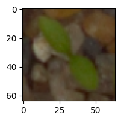

```
Predicted Label: ['Common Chickweed']
True Label: Common Chickweed
```

```
Predicted Label: ['Shepherds Purse']
True Label: Shepherds Purse
```

```python
# Visualizing the predicted and correct label of images from test data
plt.figure(figsize=(2, 2))
plt.imshow(X_test[2])
plt.show()

# Predict and display results for the first image
predicted_label = enc.inverse_transform(final_model.predict(X_test_normalized[2].reshape(1, 64, 64, 3)))
true_label = enc.inverse_transform(y_test_encoded)[2]
print('Predicted Label:', predicted_label)
print('True Label:', true_label)

plt.figure(figsize=(2, 2))
plt.imshow(X_test[33])
plt.show()

# Predict and display results for the second image
predicted_label = enc.inverse_transform(final_model.predict(X_test_normalized[33].reshape(1, 64, 64, 3)))
true_label = enc.inverse_transform(y_test_encoded)[33]
print('Predicted Label:', predicted_label)
print('True Label:', true_label)

plt.figure(figsize=(2, 2))
plt.imshow(X_test[59])
plt.show()

# Predict and display results for the third image
predicted_label = enc.inverse_transform(final_model.predict(X_test_normalized[59].reshape(1, 64, 64, 3)))
true_label = enc.inverse_transform(y_test_encoded)[59]
print('Predicted Label:', predicted_label)
print('True Label:', true_label)

plt.figure(figsize=(2, 2))
plt.imshow(X_test[36])
plt.show()

# Predict and display results for the fourth image
predicted_label = enc.inverse_transform(final_model.predict(X_test_normalized[36].reshape(1, 64, 64, 3)))
true_label = enc.inverse_transform(y_test_encoded)[36]
print('Predicted Label:', predicted_label)
print('True Label:', true_label)
```

[output not shown]

## Actionable Insights and Business Recommendations

Actionable Insights and Business Recommendations:

**Model Selection:** Model2, incorporating advanced techniques like batch normalization and dropout, demonstrates superior performance compared to Model1 on the test set. Therefore, it is advisable to opt for Model2 for deployment.

**Data Augmentation:** Utilizing data augmentation to artificially expand the training dataset is a commendable practice, enhancing the model's ability to generalize to unseen data.

**Confusion Matrix Analysis:** Analyzing the confusion matrix provides valuable insights into the model's performance across individual classes. Variations in precision and recall metrics highlight areas for potential improvement.

**Model Improvement Strategies:** Fine-tuning the model involves adjusting hyperparameters like learning rate, batch size, and epochs. Exploring alternative architectures, including deeper networks or leveraging pre-trained models for feature extraction, can further enhance performance. Consider advanced techniques such as transfer learning to capitalize on knowledge from models trained on larger datasets.

**Learning Rate Adjustment:** Model2 implements learning rate reduction on plateaus, a pivotal technique for accelerating convergence and enhancing generalization. Continuous monitoring of the learning rate during training is recommended to ensure adaptability to progress.

**Image Preprocessing:** Resizing images to 64x64 pixels reduces computational complexity. Experimenting with different preprocessing techniques or resolutions may offer insights into their impact on model performance.

**Business Recommendations:** Deploy the model for automated plant species classification in real-world scenarios. Regularly monitor model performance and consider retraining with new data to adapt to changing conditions. Prioritize data collection, particularly for classes with limited samples, to strengthen the model's ability to differentiate between underrepresented classes.

**User Interface and Interpretability:** Develop an intuitive interface for user interaction, providing insights into predictions and model confidence. Implement interpretability techniques to understand the features influencing predictions, especially for critical decisions.

**Collaboration with Domain Experts:** Engage with botanists or domain experts to enhance the model's accuracy and interpretability. Gathering domain knowledge is essential for comprehending challenges in real-world plant species classification. Continuous monitoring and improvement are crucial for sustaining the model's effectiveness. Consider the ethical implications of deployment, ensuring transparent communication with end-users regarding the model's capabilities and limitations.